# Estimated Effects for a Pre-Determined Locus

QTL Team

21:36:11 on 29 January, 2025

# 1 Introduction

This tutorial is about estimating relevant contrasts for the effects of a locus when it is fitted as a fixed effect in the model.

We will be returning to simulated data but we will continue the egg theme. Egg shell colour is of interest and assume the breeding company tests the hens for Minolta Color L’a’b’ - which is a real system of measurement. One of its components is ‘lightness’ L. We will also continue to use a pedigree relationship - which is easier for tutorial calculations.

- L was measured in 3 different environmental lighting conditions to get values `l1`, `l2`, and `l3`. However the breeding company used only `l1` in the selection index.
- When doing the measurements a calibrating variable `x0` for the machine is made for the eggs of each hen before doing measurement to help adjust for the environment.
- The hen population has been measured over multiple generations, `gen`.
- Hens lay eggs in one of 4 sheds, `lay_shed` - the same sheds and (for simplicity) assumed to have a constant effect each generation.
- One of the competitors has claimed to find a causal variant, a G/C polymorphism affecting lightness!
- The breeder uses conserved DNA from all the hens to genotype this locus, and an analysis is made to see if this claim is credible!
- The genotypes are described by 0, 1 and 2, which corresponds to the count of C alleles.

# 2 Setting up

`qgm_helpers_t6.R` is unchanged - no new qgm_helpers.

```r
library("asreml")
```

```r
library("ggplot2")
library("GGally")
source("qgm_helpers_t6.R")
```

# 3 Reading data and pedigree

## 3.1 … data

```r
tut6 <- read.table("rdat6.csv", sep=",", header=TRUE, strip.white = TRUE, na.strings=c("NA"))
head(tut6)
```

```
##   id sire dam gen lay_shed          x0 genotype         l1          l2         l3
## 1  1    0   0   0        4 -0.03522578        1 -0.5595341  0.06531302  0.2635402
## 2  2    0   0   0        2  0.46190602        0 -2.3025268 -0.94674219 -2.7719753
## 3  3    0   0   0        3  0.88966973        0  0.9415693 -1.82912515 -1.1872708
## 4  4    0   0   0        3 -1.03219019        1  0.3628976 -0.86451324 -1.0934341
## 5  5    0   0   0        2  0.80817759        1  1.3452219  0.32208399 -0.1641472
## 6  6    0   0   0        2 -0.55439726        1 -0.1811097  0.74861724 -0.7075862
```

In this particular example the identities in the data and in the pedigree are identical, and the data file repeats what is in the pedigree. It is possible to obtain the pedigree `ainv` by `ainv <- ainverse(tut6[,1:3])`, i.e. there is no need to have a separate pedigree file. However in QGM, we have always kept these separate to emphasise the different roles (and potential very different sizes) that the individuals with records and the individuals with relationship information (either from pedigree or genomic) play in the models.

Look at the three traits `l1`, `l2` and `l3` and `gen`

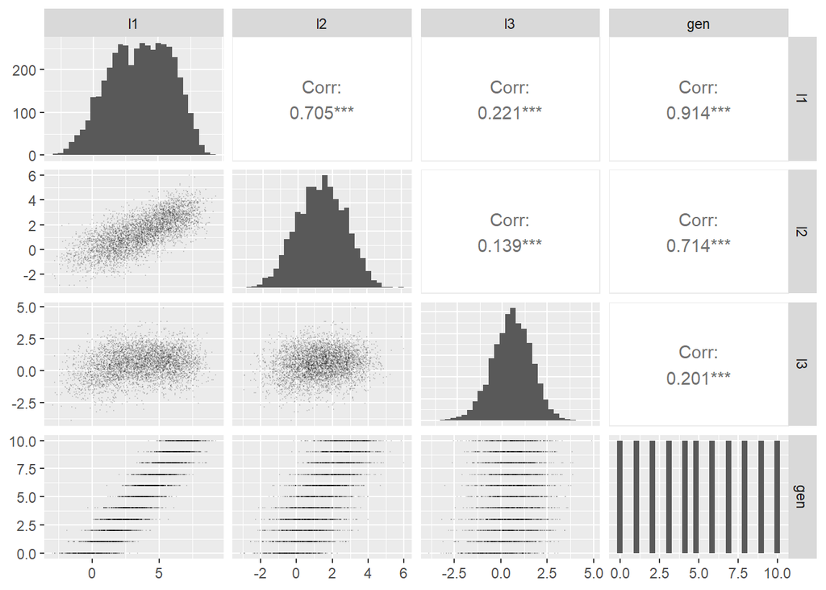

```r
ggpairs(data = tut6[,c("l1","l2","l3","gen")], diag= list(continuous= "bar", binwidth= 30), lower= list(continuous= wrap(ggally_points, size= 0.01, alpha= 0.1)))
```

### 3.1.1 Question 1

- Q1. What observations might be made about the three traits?
- $\mathbf{Answer.}$ Here are some relevant points:
  - `l1` in particular and `l2` appear to change over generations - and we are told there is no environmental trend, so it suggests some selection.
  - `l3` does not show the same trend although there are correlations in the raw data.
  - `l1`, `l2` and `l3` do not suggest any distributional challenges.
  - The data represents 11 generations.

## 3.2 … and pedigree

```r
ped6 <- read.table("rped6.csv",sep=",",header=TRUE,strip.white = TRUE,na.strings=c("NA"))
head(ped6)
```

```
##   id sire dam gen genotype
## 1  1   NA  NA   0        1
## 2  2   NA  NA   0        0
## 3  3   NA  NA   0        0
## 4  4   NA  NA   0        1
## 5  5   NA  NA   0        1
## 6  6   NA  NA   0        1
```

### 3.2.1 Question 2

- Q2. Explore the genetic structure of the pedigree - which is the same as the data.
- $\mathbf{Answer.}$ It is reminiscent of earlier data: it is the same in all details - hierarchical and balanced.

```r
qgm_ped_summary(ped6)
```

```
## [1] "Pedigree assumed ordered id, sire, dam in columns 1 to 3"
## [1] "Number of distinct ids: 4400"
## [1] " ... Maximum number of records per id: 1"
## [1] " ... Minimum number of records per id: 1"
## [1] " ... Number of distinct ids with no sire: 400"
## [1] " ... Number of distinct ids with no dam : 400"
## [1] " ... Number of distinct ids with no sire or dam: 400"
## [1] "Number of distinct sires: 100"
## [1] " ... Maximum offspring per sire : 40"
## [1] " ... Minimum offspring per sire : 40"
## [1] "Number of distinct dams : 500"
## [1] " ... Maximum offspring per dam : 8"
## [1] " ... Minimum offspring per dam : 8"
## [1] "Number of mating pairs: 500"
## [1] " ... Maximum number of sires per dam: 1"
## [1] " ... Minimum number of sires per dam: 1"
## [1] " ... Maximum number of dams per sire: 5"
## [1] " ... Minimum number of dams per sire: 5"
## [1] " ... Maximum number of offspring per pair: 8"
## [1] " ... Minimum number of offspring per pair: 8"
## [1] "Number of parents used as both sires and dams: 0"
## [1] "Number of parents used for selfing: 0"
```

```r
qgm_ped_summary(ped6[ped6$gen %in% c(0),])
```

```
## [1] "Pedigree assumed ordered id, sire, dam in columns 1 to 3"
## [1] "Number of distinct ids: 400"
## [1] " ... Maximum number of records per id: 1"
## [1] " ... Minimum number of records per id: 1"
## [1] " ... Number of distinct ids with no sire: 400"
## [1] " ... Number of distinct ids with no dam : 400"
## [1] " ... Number of distinct ids with no sire or dam: 400"
## [1] "Number of distinct sires: 0"
## [1] "Number of distinct dams : 0"
## [1] "Number of mating pairs: 0"
```

```r
qgm_ped_summary(ped6[ped6$gen %in% c(1),])
```

```
## [1] "Pedigree assumed ordered id, sire, dam in columns 1 to 3"
## [1] "Number of distinct ids: 400"
## [1] " ... Maximum number of records per id: 1"
## [1] " ... Minimum number of records per id: 1"
## [1] " ... Number of distinct ids with no sire: 0"
## [1] " ... Number of distinct ids with no dam : 0"
## [1] " ... Number of distinct ids with no sire or dam: 0"
## [1] "Number of distinct sires: 10"
## [1] " ... Maximum offspring per sire : 40"
## [1] " ... Minimum offspring per sire : 40"
## [1] "Number of distinct dams : 50"
## [1] " ... Maximum offspring per dam : 8"
## [1] " ... Minimum offspring per dam : 8"
## [1] "Number of mating pairs: 50"
## [1] " ... Maximum number of sires per dam: 1"
## [1] " ... Minimum number of sires per dam: 1"
## [1] " ... Maximum number of dams per sire: 5"
## [1] " ... Minimum number of dams per sire: 5"
## [1] " ... Maximum number of offspring per pair: 8"
## [1] " ... Minimum number of offspring per pair: 8"
## [1] "Number of parents used as both sires and dams: 0"
## [1] "Number of parents used for selfing: 0"
```

```r
qgm_ped_summary(ped6[ped6$gen %in% c(10),])
```

```
## [1] "Pedigree assumed ordered id, sire, dam in columns 1 to 3"
## [1] "Number of distinct ids: 400"
## [1] " ... Maximum number of records per id: 1"
## [1] " ... Minimum number of records per id: 1"
## [1] " ... Number of distinct ids with no sire: 0"
## [1] " ... Number of distinct ids with no dam : 0"
## [1] " ... Number of distinct ids with no sire or dam: 0"
## [1] "Number of distinct sires: 10"
## [1] " ... Maximum offspring per sire : 40"
## [1] " ... Minimum offspring per sire : 40"
## [1] "Number of distinct dams : 50"
## [1] " ... Maximum offspring per dam : 8"
## [1] " ... Minimum offspring per dam : 8"
## [1] "Number of mating pairs: 50"
## [1] " ... Maximum number of sires per dam: 1"
## [1] " ... Minimum number of sires per dam: 1"
## [1] " ... Maximum number of dams per sire: 5"
## [1] " ... Minimum number of dams per sire: 5"
## [1] " ... Maximum number of offspring per pair: 8"
## [1] " ... Minimum number of offspring per pair: 8"
## [1] "Number of parents used as both sires and dams: 0"
## [1] "Number of parents used for selfing: 0"
```

# 4 Setting up factors

We need to set up factors for the analyses.

- In this analysis `id`, `genotype` and `lay_shed` will be used as factors: `id` in the random model, `genotype` and `lay_shed` in the fixed model.
- In previous tutorials we have not fitted a covariate in the models. Here `x0` will be part of the fixed model. However it is a covariate, not a factor, and it will automatically fitted as a linear regression.
- We will not fit an environmental time trend (e.g.`gen` in this data) in the models, although in real data this would be essential!
  - we assume that we have prior knowledge that there is no environmental time trend over generations in this data - which happens to be true!
- R is annoying in that when a column is declared as a factor, it is then hard to do further calculations with it! Therefore I am duplicating the `genotype` column for use later, `c_gen`.

```r
tut6$c_gen <- tut6$genotype
tut6$genotype <- factor(tut6$genotype)
tut6$id <- factor(tut6$id)
tut6$lay_shed <- factor(tut6$lay_shed)
```

# 5 Obtain inverse of A

```r
ainv <- ainverse(ped6[,1:3])
```

# 6 Fitting models to `l1`

## 6.1 The polygenic model

The appropriate model includes the polygenic additive genetic variance to account for genetic variation not explained by the G/C polymorphism. Prior to fitting the model remember an initial interest of the study is the effect of the G/C polymorphism and initial objectives are to estimate the additive `a` and dominance `d`.

- `a` is the contrast (-0.5, 0.0, 0.5)
- `d` is the contrast (-0.5, 1.0, -0.5)

```r
c_a <- c(-0.5, 0.0, 0.5)
c_d <- c(-0.5, 1.0, -0.5)
```

Therefore when fitting the model, as well as looking at `qgm_summary()`, also look at the estimate of `a` for `l1` using `qgm_fixed_linear()`.

```r
asr <- asreml(fixed= l1 ~1 +lay_shed +x0 +genotype, random= ~vm(id,ainv), residual= ~idv(units), data= tut6)
qgm_summary(asr)
```

```
## [1] "CONVERGENCE: TRUE with logL = -1734.13830634114"
##
## [1] "VARIANCE COMPONENTS"
##
##
## |             | component| std.error|  z.ratio|bound | %ch|
## |:------------|---------:|---------:|--------:|:-----|---:|
## |vm(id, ainv) | 0.5207358| 0.0332945| 15.64031|P     |   0|
## |units!units  | 0.4858086| 0.0194312| 25.00148|P     |   0|
## |units!R      | 1.0000000|        NA|       NA|F     |   0|
##
## [1] "FIXED EFFECTS"
##
##
## |            |   solution| std error|    z.ratio|
## |:-----------|----------:|---------:|----------:|
## |(Intercept) | -0.7518092| 0.0758865| -9.9070239|
## |lay_shed_1  |  0.0000000|        NA|         NA|
## |lay_shed_2  |  0.0826798| 0.0502910|  1.6440277|
## |lay_shed_3  |  0.0718232| 0.0474087|  1.5149786|
## |lay_shed_4  |  0.0878194| 0.0459859|  1.9097026|
## |x0          |  0.0005278| 0.0131631|  0.0400965|
## |genotype_0  |  0.0000000|        NA|         NA|
## |genotype_1  |  0.9458133| 0.0767210| 12.3279666|
## |genotype_2  |  1.3016453| 0.0904476| 14.3911530|
##
## [1] "WALD TESTS"
##
##
## |            | Df|  denDF|     F.con|Pr     |
## |:-----------|--:|------:|---------:|:------|
## |(Intercept) |  1| 2293.5| 6.324e+00|0.0120 |
## |lay_shed    |  3| 4273.3| 1.265e+00|0.2846 |
## |x0          |  1| 4274.3| 1.619e-03|0.9679 |
## |genotype    |  2| 3799.4| 1.061e+02|0.0000 |
```

```r
qgm_fixed_linear(asr,"genotype",c_a)
```

```
##    Estimate       S.E.
## 1 0.6508428 0.04522256
```

```r
qgm_fixed_linear(asr,"genotype",c_d)
```

```
##    Estimate       S.E.
## 1 0.2949868 0.05189799
```

## 6.2 No polygenic effect

Consider the model that has no polygenic additive term.

```r
asr_no <- asreml(fixed= l1 ~1 +lay_shed +x0 +genotype, residual= ~idv(units), data= tut6)
qgm_summary(asr_no)
```

```
## [1] "CONVERGENCE: TRUE with logL = -4860.44969279138"
##
## [1] "VARIANCE COMPONENTS"
##
##
## |            | component| std.error|  z.ratio|bound | %ch|
## |:-----------|---------:|---------:|--------:|:-----|---:|
## |units!units |  3.326604| 0.0709799| 46.86683|P     |   0|
## |units!R     |  1.000000|        NA|       NA|F     |   0|
##
## [1] "FIXED EFFECTS"
##
##
## |            |   solution| std error|    z.ratio|
## |:-----------|----------:|---------:|----------:|
## |(Intercept) | -0.5773736| 0.1404418| -4.1111234|
## |lay_shed_1  |  0.0000000|        NA|         NA|
## |lay_shed_2  |  0.1555401| 0.1052885|  1.4772753|
## |lay_shed_3  |  0.1596925| 0.0991382|  1.6108066|
## |lay_shed_4  |  0.2631308| 0.0962654|  2.7333888|
## |x0          |  0.0022076| 0.0276033|  0.0799747|
## |genotype_0  |  0.0000000|        NA|         NA|
## |genotype_1  |  1.5474358| 0.1338839| 11.5580424|
## |genotype_2  |  4.7414534| 0.1162805| 40.7760022|
##
## [1] "WALD TESTS"
##
##
## |            | Df| denDF|     F.con|Pr     |
## |:-----------|--:|-----:|---------:|:------|
## |(Intercept) |  1|  4393| 1.722e+04|0.0000 |
## |lay_shed    |  3|  4393| 2.769e+00|0.0402 |
## |x0          |  1|  4393| 6.396e-03|0.9363 |
## |genotype    |  2|  4393| 1.490e+03|0.0000 |
```

```r
qgm_fixed_linear(asr_no,"genotype",c_a)
```

```
##   Estimate       S.E.
## 1 2.370727 0.05814024
```

```r
qgm_fixed_linear(asr_no,"genotype",c_d)
```

```
##     Estimate       S.E.
## 1 -0.8232909 0.09341566
```

### 6.2.1 Question 3 to 5

- Q3. What is the impact of the polygenic term on the estimates of `a` and `d`?
- $\mathbf{Answer.}$ With polygenic ‘a’ is 0.651 (s.e. 0.045), ‘d’ is 0.295 (s.e. 0.052); Without polygenic ‘a’ is 2.371 (s.e. 0.058), ‘d’ is -0.823 (s.e. 0.093). The term has a major impact for both!
- Q4. Which of these models is the better estimate of the true additive effect of the G/C polymorphism?
- $\mathbf{Answer.}$ It is the polygenic model . unless one assumes $V_a$ is zero $\textit{a priori}$ (which is in my view unacceptable biologically!) and the model then collapses to the non-polygenic model.
- Q5. What is the test statistic for a LRT of H0: polygenic $V_a$ =0 against an alternative H1: polygenic $V_a$ >0. Is it significant at P<0.001?
- $\mathbf{Answer.}$ The test statistic is twice the difference in the log-likelihoods which is 6253. The critical value for Type 1 error of 0.001 is 9.550, so reject H0.

```r
logl0 <- -4860.450
logl1 <- -1734.138
2*(logl1-logl0)
```

```
## [1] 6252.624
```

```r
qchisq(0.998, 1, lower.tail=TRUE)
```

```
## [1] 9.549536
```

## 6.3 Contrasts estimated in the polygenic model

Repeat the contrasts to obtain the estimates for `a` and `d` using the correct model.

```r
qgm_fixed_linear(asr,"genotype",c_a)
```

```
##    Estimate       S.E.
## 1 0.6508428 0.04522256
```

```r
qgm_fixed_linear(asr,"genotype",c_d)
```

```
##    Estimate       S.E.
## 1 0.2949868 0.05189799
```

### 6.3.1 Questions 6 to 9

- Q6. What are the approximate d.f. for any approximate t-test involving `genotype` in the polygenic model?
- $\mathbf{Answer.}$ Look in the genotype row of the Wald effects data frame from qgm_summary() and round down 3799.
- Q7. Carry out an approximate t-test with Type 1 error = 0.05, of H0: `a`=0.7 against an alternative H1: not H0. Note this is a 2-sided test.
- $\mathbf{Answer.}$ The test statistic is |0.651-0.7|/0.045 = 1.089 where |x| is absolute value. The critical value for a two-sided test (so probability 0.025 at both upper and lower tails) is 1.961 (from qt(0.975,3799,lower.tail=TRUE)). There is no evidence to reject H0 with this Type 1 error.
- Q8. Repeat Q7 for testing H0: `d`=0.3 against an alternative H1: not H0 with same Type 1 error.
- $\mathbf{Answer.}$ The test statistic is |0.295-0.3|/0.052 = 0.097. The critical value for the two-sided test is as Q7. There is no evidence to reject H0 with this Type 1 error.
- Q9. The true values in the simulation were `a` = 0.7 and `d` = 0.3. Consider your answers to Q3. How well do they agree with the conclusions of Kennedy et al. given in Lecture 6?
- $\mathbf{Answer.}$ Yes, definitely. It also shows that although Kennedy et al. suggest that ‘d’ may often be less affected substantial biases can occur.

```r
abs(0.65084-0.7)/0.04522
```

```
## [1] 1.08713
```

```r
abs(0.29499-0.3)/0.05190
```

```
## [1] 0.09653179
```

```r
qt(0.975, 3799, lower.tail=TRUE)
```

```
## [1] 1.960589
```

## 6.4 More contrasts

### 6.4.1 Allele frequencies

Some of the contrasts in Lecture 5, such as the effect of allelic substitution and average effects depend on the allele frequency. The allele frequency of the C allele can be calculated for a generation as below. The C allele was fixed by generation 6.

```r
cfreq <- data.frame(gen= numeric(length=11), p= numeric(length=11))
for (i in 0:10) {
  cfreq[i+1,"gen"] <- i
  cfreq[i+1,"p"] <- mean(tut6[tut6$gen %in% c(i),"c_gen"])/2. # remember it is an allele count (0,1,2) so divide by 2!
}
cfreq
```

```
##    gen       p
## 1    0 0.30625
## 2    1 0.61125
## 3    2 0.80125
## 4    3 0.88625
## 5    4 0.95750
## 6    5 0.99625
## 7    6 1.00000
## 8    7 1.00000
## 9    8 1.00000
## 10   9 1.00000
## 11  10 1.00000
```

### 6.4.2 Questions 10 to 16

ASSUME for simplicity the allele frequencies for C of 0.3 in the base generation and 0.8 in generation 2 and use `qgm_fixed_linear()`.

- Q10. What is the estimated effect of an allelic substitution for allele C in the base generation?
- $\mathbf{Answer.}$ See table below.
- Q11. What is the estimated effect of an allelic substitution for allele C in generation 2?
- $\mathbf{Answer.}$ See table below.
- Q12. What would the difference in the answers for Q10 and Q11 be if the estimate of `d` was 0?
- $\mathbf{Answer.}$ The difference would be 0. The effect of allelic substitution depends on allele frequency only through $d$ as it is `a`+(q-p)`d`.
- Q13. What are the average effects for alleles C and G in the base?
- $\mathbf{Answer.}$ See table below.
- Q14. What is the contribution to the total breeding value made by the G/C polymorphism for hens `id` = 1 and `id` = 2?
- $\mathbf{Answer.}$ The contribution to the EBV is the sum of the estimates of the average effects: so ‘1’ is a CG heterozygote and is the sum of the two average effects, ‘2’ is a GG and so contribution is simply twice the average effect of G.
- Q15. What are the average effects for alleles C and G in generation 2?
- $\mathbf{Answer.}$
- Q16. What is the average effects for alleles C and G in generations 6 and beyond?
- $\mathbf{Answer.}$ The locus still has a substitution effect of `a`-`d` = 0.356 (see table below), even if not segregating. C will have an average effect of 0 (the C is fixed) and G if it appeared would have an estimated average effect of -0.356. The positive dominance softens the impact of the appearance of a G allele, as a very rare G allele will only appear as a heterozygote.

| Question | Description | Contrast | Estimate | s.e. |
| --- | --- | --- | --- | --- |
| 10 | allelic substitution of C in gen 0 | -0,7,0.4,0.3 | 0.769 | 0.054 |
| 11 | allelic substitution of C in gen 2 | -0.2,-0.6,0.8 | 0.474 | 0.048 |
| 13 | average effect of C in gen 0 | -0.49,0.28,0.21 | 0.538 | 0.038 |
| 13 | average effect of G in gen 0 | 0.21,-0.12,-0.09 | -0.231 | 0.016 |
| 14 | contribution to EBV for ‘1’ (CG) | -0.28,0.16,0.12 | 0.308 | 0.022 |
| 14 | contribution to EBV for ‘2’ (GG) | 0.42,-0.24,-0.18 | -0.461 | 0.033 |
| 15 | average effect of C in gen 2 | -0.04,-0.12,0.16 | 0.095 | 0.010 |
| 15 | average effect of G in gen 2 | 0.16,0.48,-0.64 | -0.379 | 0.039 |
| 16 | allelic substitution of C when fixed | 0.0,-1.0,1.0 | 0.356 | 0.060 |

```r
c_alpha0 <- c(-0.7, 0.4, 0.3)
c_G0 <- -0.3*c_alpha0
c_C0 <- 0.7*c_alpha0
c_alpha2 <- c(-0.2, -0.6, 0.8)
c_G2 <- -0.8*c_alpha2
c_C2 <- 0.2*c_alpha2
c_alpha6 <- c(0.0, -1.0, 1.0)
# note ... c_G6 <- -1*c_alpha6
# note ... c_C6 <-  0*c_alpha6
qgm_fixed_linear(asr,"genotype",c_alpha0)  #10
```

```
##    Estimate       S.E.
## 1 0.7688375 0.05417556
```

```r
qgm_fixed_linear(asr,"genotype",c_G0)      #13
```

```
##     Estimate       S.E.
## 1 -0.2306512 0.01625267
```

```r
qgm_fixed_linear(asr,"genotype",c_C0)      #13
```

```
##    Estimate       S.E.
## 1 0.5381862 0.03792289
```

```r
qgm_fixed_linear(asr,"genotype",c_alpha2)  #11
```

```
##    Estimate       S.E.
## 1 0.4738507 0.04823126
```

```r
qgm_fixed_linear(asr,"genotype",c_G2)      #15
```

```
##     Estimate       S.E.
## 1 -0.3790806 0.03858501
```

```r
qgm_fixed_linear(asr,"genotype",c_C2)      #15
```

```
##     Estimate        S.E.
## 1 0.09477014 0.009646252
```

```r
qgm_fixed_linear(asr,"genotype",2*c_G0)    #14
```

```
##     Estimate       S.E.
## 1 -0.4613025 0.03250533
```

```r
qgm_fixed_linear(asr,"genotype",c_G0+c_C0) #14
```

```
##   Estimate       S.E.
## 1 0.307535 0.02167022
```

```r
qgm_fixed_linear(asr,"genotype",c_alpha6)  #16
```

```
##   Estimate       S.E.
## 1 0.355856 0.05992549
```

# 7 Fitting a model to `l2`

There is considerable published evidence that the there is a genetic relationship between `l1` and `l2` - and the trellis plot above supports this. `l2` was not selected upon directly, but `l1` was.

## 7.1 Questions 17 to 20

- Q17. What is an appropriate model to estimate the effect of the G/C polymorphism on `l2`?
- $\mathbf{Answer.}$ Bivariate model with `l1` as it is stated that selection was for `l1` and the information on selection should be included to avoid bias (wherever feasible, and it is feasible in this case).
- Q18. What are the best estimates of `a` and `d` for the G/C polymorphism on `l2` when fitting the appropriate model? Note `qgm_fixed_linear()` does not deal with multivariate models so the s.e.s take extra code, so just calculate the effects for this question.
- $\mathbf{Answer.}$ `a` for `l2` is 0.148 (s.e. 0.045), `d` is 0.033 (s.e. 0.051).
- Q19. The true value for `l2` is `a` = 0.2, `d` = 0. What are your conclusions? (Give a reasoned argument, no need to do a formal test, you may assume approximate s.e.s of 0.05).
- $\mathbf{Answer.}$ The estimates are close to the true values, agreeing with Kennedy et al. that the polygenic model should remove bias.
- Q20. Confirm your earlier conclusions on bias by comparing the estimates in Q17 for `a` and `d` to those obtained when a univariate model is fitted with no polygenic additive effect.
- $\mathbf{Answer.}$ There is a large bias in both estimates ‘a’ for `l2` is 0.920 (s.e. 0.040), ‘d’ is -0.375 (s.e. 0.064).

```r
asr2 <- asreml(fixed= cbind(l1,l2) ~trait +trait:lay_shed +trait:x0 +trait:genotype, random= ~us(trait):vm(id,ainv), residual= ~id(units):us(trait), data= tut6)
asr2 <- qgm_continue(asr2,10)
qgm_summary(asr2)
```

```
## [1] "CONVERGENCE: TRUE with logL = -3361.25462127578"
##
## [1] "VARIANCE COMPONENTS"
##
##
## |                               |  component| std.error|    z.ratio|bound | %ch|
## |:------------------------------|----------:|---------:|----------:|:-----|---:|
## |trait:vm(id, ainv)!trait_l1:l1 |  0.5156717| 0.0324854| 15.8739764|P     |   0|
## |trait:vm(id, ainv)!trait_l2:l1 |  0.2357896| 0.0267986|  8.7985797|P     |   0|
## |trait:vm(id, ainv)!trait_l2:l2 |  0.5296200| 0.0436033| 12.1463330|P     |   0|
## |units:trait!R                  |  1.0000000|        NA|         NA|F     |   0|
## |units:trait!trait_l1:l1        |  0.4883066| 0.0191598| 25.4859442|P     |   0|
## |units:trait!trait_l2:l1        | -0.0011388| 0.0149817| -0.0760139|P     |   0|
## |units:trait!trait_l2:l2        |  0.4691094| 0.0243205| 19.2886771|P     |   0|
##
## [1] "FIXED EFFECTS"
##
##
## |                    |   solution| std error|    z.ratio|
## |:-------------------|----------:|---------:|----------:|
## |trait_l1            | -0.7555981| 0.0757119| -9.9799094|
## |trait_l2            | -0.3970868| 0.0753374| -5.2707810|
## |trait_l1:lay_shed_1 |  0.0000000|        NA|         NA|
## |trait_l1:lay_shed_2 |  0.0809448| 0.0502134|  1.6120150|
## |trait_l1:lay_shed_3 |  0.0699978| 0.0473356|  1.4787581|
## |trait_l1:lay_shed_4 |  0.0862439| 0.0459151|  1.8783346|
## |trait_l2:lay_shed_1 |  0.0000000|        NA|         NA|
## |trait_l2:lay_shed_2 |  0.0343181| 0.0497567|  0.6897184|
## |trait_l2:lay_shed_3 |  0.0544174| 0.0469080|  1.1600891|
## |trait_l2:lay_shed_4 |  0.0622429| 0.0454980|  1.3680343|
## |trait_l1:x0         | -0.0000957| 0.0131427| -0.0072827|
## |trait_l2:x0         | -0.0173753| 0.0130235| -1.3341518|
## |trait_l1:genotype_0 |  0.0000000|        NA|         NA|
## |trait_l1:genotype_1 |  0.9484488| 0.0764270| 12.4098722|
## |trait_l1:genotype_2 |  1.3140619| 0.0899565| 14.6077472|
## |trait_l2:genotype_0 |  0.0000000|        NA|         NA|
## |trait_l2:genotype_1 |  0.1805140| 0.0760506|  2.3736035|
## |trait_l2:genotype_2 |  0.2954820| 0.0896672|  3.2953200|
##
## [1] "WALD TESTS"
##
##
## |               | Df|  denDF|   F.con|Pr     |
## |:--------------|--:|------:|-------:|:------|
## |trait          |  2| 1822.1| 14.1100|0.0000 |
## |trait:lay_shed |  6| 5629.0|  0.8756|0.5118 |
## |trait:x0       |  2| 4227.2|  0.9078|0.4035 |
## |trait:genotype |  4| 4146.1| 54.5000|0.0000 |
```

```r
c_t2a <- c(0,-0.5, 0,0, 0,0.5)
c_t2d <- c(0,-0.5, 0,1, 0,-0.5)
qgm_fixed_linear(asr2,"trait:genotype", c_t2a)
```

```
##   Estimate       S.E.
## 1 0.147741 0.04483358
```

```r
qgm_fixed_linear(asr2,"trait:genotype", c_t2d)
```

```
##     Estimate       S.E.
## 1 0.03277302 0.05137754
```

```r
asr3 <- asreml(fixed= l2 ~1 +lay_shed +x0 +genotype, residual= ~idv(units), data= tut6)
qgm_fixed_linear(asr3,"genotype", c_a)
```

```
##    Estimate       S.E.
## 1 0.9203691 0.03975671
```

```r
qgm_fixed_linear(asr3,"genotype", c_d)
```

```
##     Estimate       S.E.
## 1 -0.3753972 0.06387829
```

# 8 Outcomes

- We have shown the bias arising from not including polygenic variation when estimating loci as fixed effects
  - note that fitting with fixed effects is what is done in GWAS!
  - hence, the importance of accounting for other polygenic variation in GWAS!
- We have shown biases due to selection
- We have used contrasts to estimate useful genetic parameters that describe the allelic effects and the contribution of the locus to breeding values.